# Exploratory and Unsupervised Analysis of TCGA Prostate Cancer Transcriptomic Data

Juan Bizzotto

## Introduction

In this notebook, we explore the transcriptomic and clinical data from the TCGA Prostate Adenocarcinoma (PRAD) cohort. The goal is to perform **data exploration** and apply **unsupervised machine learning methods** such as **hierarchical clustering**, **k-means**, and **dimensionality reduction** techniques (PCA and t-SNE).

We use three datasets located in the `data/` folder:

- `feno.RDS`: Clinical and phenotypic data.
- `exp.RDS`: Complete gene expression matrix (RNA-Seq).
- `exp_top.RDS`: A subset of the expression matrix including the top most variable genes, useful for clustering and visualization.

## Load Required Packages

```r
library(ggplot2)
library(tidyverse)
library(pheatmap)
library(broom)
library(skimr)
library(gtsummary)
library(ggfortify)
library(Rtsne)
```

## Load Data

```r
feno <- readRDS("data/feno.RDS")
exp <- readRDS("data/exp.RDS")
exp_top <- readRDS("data/exp_top.RDS")
```

## Initial Data Inspection

```r
dim(exp)
```

```
[1] 20530   549
```

```r
dim(exp_top)
```

```
[1] 549 100
```

We can also take a glimpse of the data structures:

```r
glimpse(feno)
```

```
Rows: 549
Columns: 16
$ sample_type                         <fct> Primary Tumor, Primary Tumor, Primary Tumor, Primary Tumor,…
$ age                                 <int> 51, 57, 47, 52, 70, 54, 69, 57, 57, 56, 64, 73, 72, 65, 57,…
$ initial_weight                      <int> 140, 110, 140, 140, 160, 140, 150, 150, 80, 140, 380, NA, N…
$ histological_type                   <chr> "Prostate Adenocarcinoma Acinar Type", "Prostate Adenocarci…
$ ISUP_group                          <fct> 1, 1, 5, 1, 4, 3, 5, 2, 1, 1, 4, 3, 1, 2, 2, 5, 2, 3, 2, 2,…
$ clinical_T_simple                   <fct> NA, T1, T2, T2, T2, T1, T2, T1, T1, T1, T2, NA, NA, NA, NA,…
$ pathologic_T_simple                 <fct> T2, T3, T4, T2, T3, T3, T3, T3, T2, T3, T3, T2, NA, T3, T2,…
$ laterality                          <chr> "Left", "Bilateral", "Bilateral", "Right", "Bilateral", "Le…
$ PFI                                 <int> 0, 0, 0, 0, 0, 0, 1, 0, 0, 0, 0, 0, 0, 0, 0, 0, 1, 0, 0, 0,…
$ PFI.time                            <int> 621, 1701, 1373, 671, 1378, 112, 198, 1364, 1272, 615, 350,…
$ PSA                                 <dbl> 2.7, 5.0, 44.9, 5.6, 2.4, 7.0, 7.1, 11.6, 4.6, 8.4, 8.4, 14…
$ targeted_molecular_therapy          <fct> NO, NO, YES, NO, NO, NA, NO, NO, NO, NO, YES, NA, NO, NO, N…
$ radiation_therapy                   <fct> NO, NO, YES, NO, NO, NA, NO, NO, NO, NO, NO, NA, NO, NO, NA…
$ is_ffpe                             <chr> "NO", "NO", "NO", "NO", "NO", "NO", "NO", "NO", "NO", "NO",…
$ initial_pathologic_diagnosis_method <chr> "Core needle biopsy", "Core needle biopsy", "Core needle bi…
$ progression                         <lgl> NA, FALSE, FALSE, NA, FALSE, NA, TRUE, FALSE, FALSE, NA, NA…
```

## Preprocessing

We will:

1. Transpose the expression matrix to have genes as columns.
2. Remove genes that have zero expression across all samples.
3. Filter to include only primary tumor samples.
4. Synchronize sample IDs across datasets.
5. Recode the ISUP group as an ordered factor.

```r
exp <- t(exp)
exp <- exp[, colSums(exp != 0) > 0]

# Keep only primary tumor samples
feno <- feno %>% filter(sample_type == "Primary Tumor")
exp <- exp[rownames(feno), ]
exp_top <- exp_top[rownames(feno), ]

# Set ISUP group as ordered factor
feno$ISUP_group <- factor(feno$ISUP_group, ordered = TRUE)
feno <- droplevels(feno)

# Add numeric version of ISUP group
feno$ISUP_group_num <- as.numeric(feno$ISUP_group)
```

## Clinical Summary Table

We summarize the clinical characteristics using `gtsummary`.

```r
feno %>%
  tbl_summary(
    statistic = list(
      all_continuous() ~ "{mean} ({sd})",
      all_categorical() ~ "{n} ({p}%)"
    ),
    digits = all_continuous() ~ 2
  )
```

| **Characteristic** | **N = 497**<sup>1</sup> |
| --- | --- |
| sample_type |  |
| Primary Tumor | 497 (100%) |
| age | 61.02 (6.82) |
| initial_weight | 243.13 (293.09) |
| Unknown | 227 |
| histological_type |  |
| Prostate Adenocarcinoma Acinar Type | 482 (97%) |
| Prostate Adenocarcinoma, Other Subtype | 15 (3.0%) |
| ISUP_group |  |
| 1 | 45 (9.1%) |
| 2 | 146 (29%) |
| 3 | 101 (20%) |
| 4 | 64 (13%) |
| 5 | 141 (28%) |
| clinical_T_simple |  |
| T1 | 177 (44%) |
| T2 | 173 (43%) |
| T3 | 53 (13%) |
| T4 | 2 (0.5%) |
| Unknown | 92 |
| pathologic_T_simple |  |
| T2 | 187 (38%) |
| T3 | 293 (60%) |
| T4 | 10 (2.0%) |
| Unknown | 7 |
| laterality |  |
| Bilateral | 432 (88%) |
| Left | 19 (3.9%) |
| Right | 38 (7.8%) |
| Unknown | 8 |
| PFI | 93 (19%) |
| PFI.time | 964.55 (756.34) |
| PSA | 11.05 (12.37) |
| Unknown | 15 |
| targeted_molecular_therapy | 52 (12%) |
| Unknown | 50 |
| radiation_therapy | 59 (13%) |
| Unknown | 49 |
| is_ffpe |  |
| NO | 440 (100%) |
| Unknown | 57 |
| initial_pathologic_diagnosis_method |  |
| Core needle biopsy | 477 (97%) |
| Transurethral resection (TURBT) | 15 (3.0%) |
| Unknown | 5 |
| progression | 72 (30%) |
| Unknown | 254 |
| ISUP_group_num |  |
| 1 | 45 (9.1%) |
| 2 | 146 (29%) |
| 3 | 101 (20%) |
| 4 | 64 (13%) |
| 5 | 141 (28%) |

<sup>1</sup> n (%); Mean (SD)

## Unsupervised Clustering

### Hierarchical Clustering with Heatmap

We use the top variable genes (`exp_top`) to reduce dimensionality for visualization.

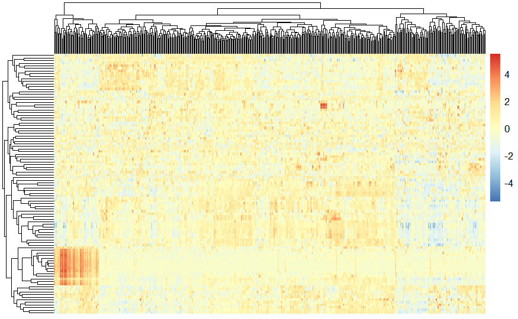

```r
pheatmap(t(exp_top), show_rownames = FALSE, show_colnames = FALSE, scale = "row")
```

Now we add clinical annotations to the heatmap.

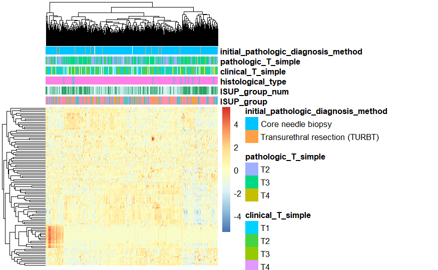

```r
annotations <- data.frame(feno %>%
                            select(ISUP_group,
                                   ISUP_group_num,
                                   histological_type,
                                   clinical_T_simple,
                                   pathologic_T_simple,
                                   initial_pathologic_diagnosis_method))

pheatmap(t(exp_top),
         scale = "row",
         annotation = annotations,
         show_rownames = FALSE,
         show_colnames = FALSE)
```

## Principal Component Analysis (PCA)

We apply PCA on the full expression matrix and visualize the principal components.

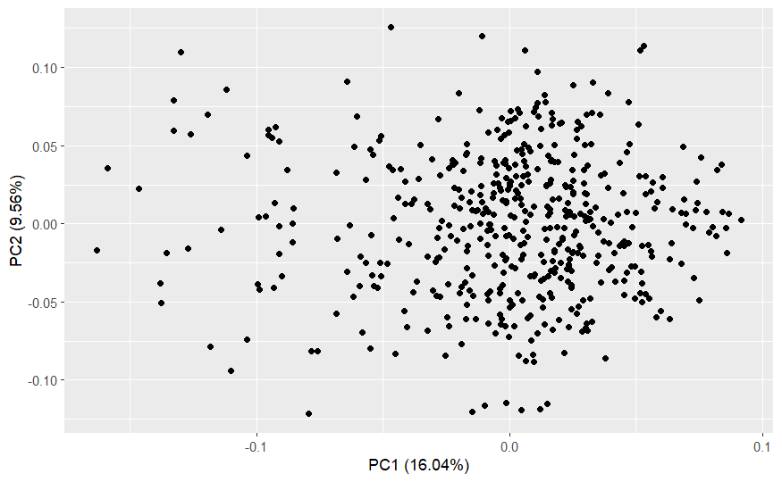

```r
exp <- exp[, colSums(exp != 0) > 0]
pca <- prcomp(exp, scale. = TRUE)
autoplot(pca)
```

We can also color the PCA plot by clinical covariates:

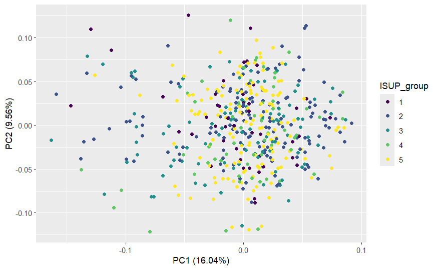

```r
autoplot(pca, data = feno, colour = "ISUP_group")
```

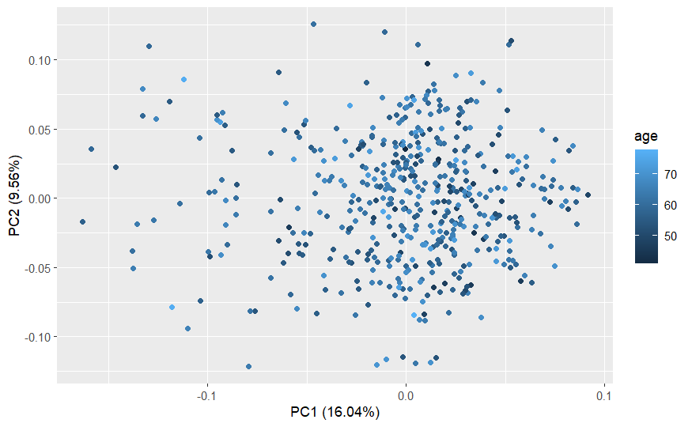

```r
autoplot(pca, data = feno, colour = "age")
```

## K-Means Clustering

We apply k-means clustering using 5 clusters on the `exp_top` matrix.

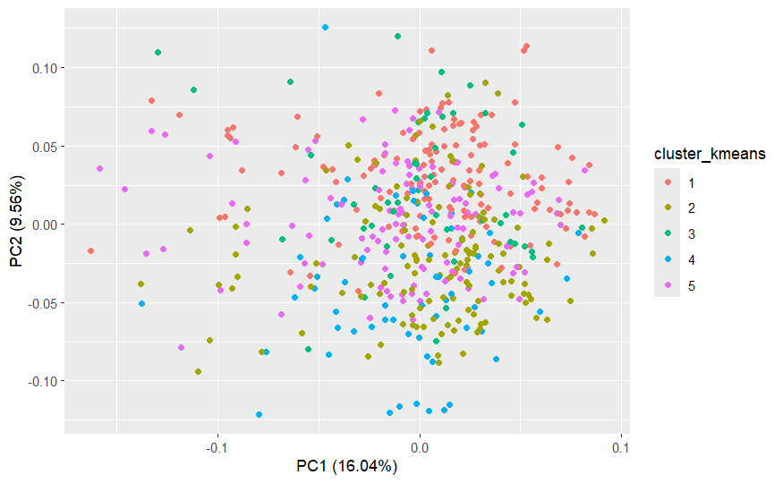

```r
set.seed(123)
km <- kmeans(exp_top, centers = 5, nstart = 25)
feno$cluster_kmeans <- factor(km$cluster)

# Visualize clusters in PCA space
autoplot(pca, data = feno, colour = "cluster_kmeans")
```

## Dimensionality Reduction with t-SNE

We use t-SNE to project samples into two dimensions and visualize the separation between clusters and clinical groups.

```r
set.seed(123)
tsne <- Rtsne(exp_top, perplexity = 30)
```

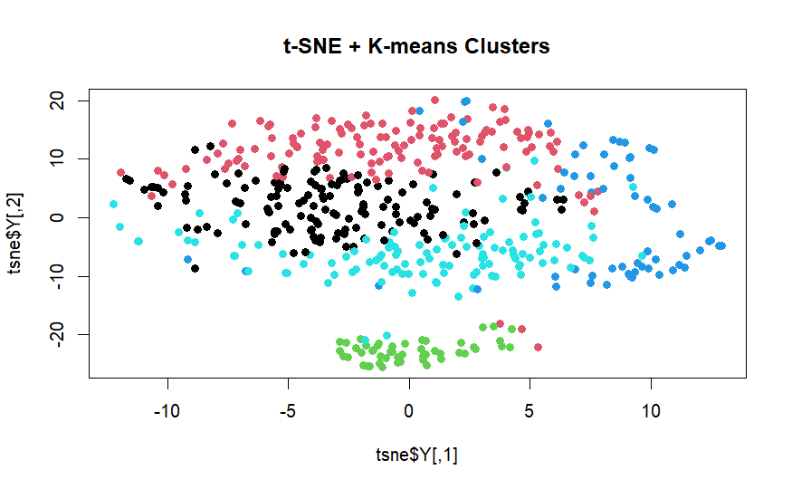

```r
plot(tsne$Y, col = km$cluster, pch = 19, main = "t-SNE + K-means Clusters")
```

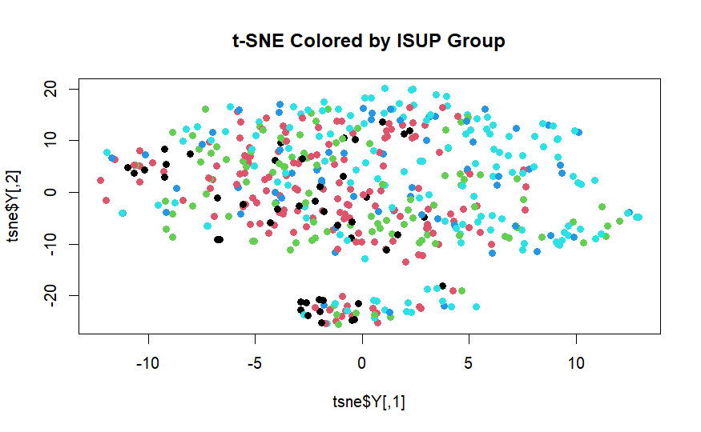

```r
plot(tsne$Y, col = feno$ISUP_group, pch = 19, main = "t-SNE Colored by ISUP Group")
```

## Clinical Association Example

Finally, we test whether the identified clusters differ in clinical features. Here, we compare PSA levels across k-means clusters.

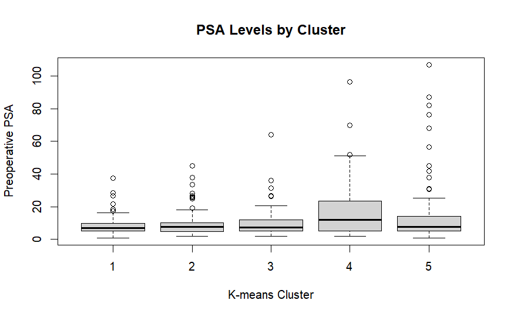

```r
boxplot(feno$PSA ~ feno$cluster_kmeans,
        xlab = "K-means Cluster",
        ylab = "Preoperative PSA",
        main = "PSA Levels by Cluster")
```